# Predicting Average Views on Twitch

Ben Gutierrez

2022-07-11

Set up global parameters

# 1 Markdown

```r
# Load libraries
library(tidyverse)
library(dplyr)
library(ggpubr)
library(Stat2Data)
library(corrplot)
library(olsrr)
library(sf)
library(tmap)
library(readxl)
library(plotly)
library(nortest)
library(skimr)
library(ggplot2)
library(car)
library(lmtest)
library(MASS)
```

# 2 Top 8800 Twitch Streamers

## 2.1 Q1: Problem Statement

Twitch.tv is a popular platform for video streaming. It is extremely popular with younger audiences since allows sharing live gameplay for others to watch and comment on in real time. Any person with a Twitch account can broadcast their games (as long as they have the right equipment); however, being a successful Twitch streamer is not only a matter of pride, it is also a good source of income. Popular Twitch streamers get in average $250 a month for every 100 subscribers in addition of ad revenue. Lately, due to the COVID-19 pandemic that forced many people to stay at home, Twitch.tv has massively increased in overall watch time and in popularity. For this reason, I decided to study a dataset that compiles the statistics of the top 8800 Twitch streamers from 6 months ago (I got the data on Kagle). My intention is to find a model to predict the popularity of a Twitch streamer which I define as this person’s average number of viewers per stream.

```r
# Loading in the data
twitch <- read.csv("TwitchDataSet.csv")
names(twitch)
```

```
##  [1] "profile.picture"  "top.count"        "screen.name"      "watch.time"
##  [5] "stream.time"      "peak.viewers"     "average.viewers"  "followers"
##  [9] "followers.gained" "views.gained"     "partnered"        "mature"
## [13] "language"         "completa.name"    "first.category"   "second.category"
## [17] "third.category"
```

The data collected has information on the top 8800 Twitch streamers. The top 8800 streamers from this dataset is defined solely on overall watch time a streamer has. With this information I hope to determine what are the most likely predictors of a streamers average viewers per stream. There are 17 pieces of data collected from the dataset. Some of the collected data is not that useful because it is specific to the observation. These include profile.picture, top.count, screen.name, and completa.name. These are the variables that are definitely not useful to regression. From the rest of the 13 variables, average.viewers is the response variable. This variable represents the average amount of viewers the streamer had per stream in a one year period from October 2019 - October 2020. Next I will explain all the potential predictors of the average.viewers (Every variable is calculated over the same one year period October 2019 - October 2020):

- **watch.time** represents the total minutes spent watching a streamer from all viewers over the one year time period.
- **stream.time** represents the total minutes a streamer streamed over the one year period.
- **peak.viewers** represents the maximum number of viewers a streamer had during any stream over the one year period.
- **followers** represents the amount of viewers who follow the streamer on their twitch account.
- **followers.gained** represents the amount of followers a streamer gained over the one year period.
- **views.gained** represents the number of individual views a streamer gained over the one year period.
- **partnered** represents whether a streamer is partnered with a twitch or not.
- **mature** represents whether a streamer’s content is made of mature audiences or not.
- **language** represents the designated language of a streamer.
- **first.category** represents the most streamed category(game or activity) of the streamer.
- **second.category** represents the second most streamed category(game or activity) of the streamer.
- **third.category** represents the third most streamed category(game or activity) of the streamer.

I believe that this data is suitable to assess the average viewers of the top streamers, but might not work for newer streamers without a big following because all the streamers I have data for will have significantly more viewers, followers, etc than many streamers on the platform.

## 2.2 Q2: Data description

```r
# Understanding the data
skim(twitch)
```

Data summary

| Name | twitch |
| --- | --- |
| Number of rows | 8800 |
| Number of columns | 17 |
| _______________________ |  |
| Column type frequency: |  |
| character | 7 |
| logical | 2 |
| numeric | 8 |
| ________________________ |  |
| Group variables | None |

**Variable type: character**

| skim_variable | n_missing | complete_rate | min | max | empty | n_unique | whitespace |
| --- | --- | --- | --- | --- | --- | --- | --- |
| profile.picture | 0 | 1 | 142 | 169 | 0 | 8778 | 0 |
| screen.name | 0 | 1 | 3 | 47 | 0 | 8800 | 0 |
| language | 0 | 1 | 0 | 23 | 1 | 31 | 0 |
| completa.name | 0 | 1 | 3 | 47 | 0 | 8800 | 0 |
| first.category | 0 | 1 | 3 | 59 | 0 | 404 | 0 |
| second.category | 0 | 1 | 3 | 62 | 0 | 685 | 0 |
| third.category | 0 | 1 | 3 | 67 | 0 | 845 | 0 |

**Variable type: logical**

| skim_variable | n_missing | complete_rate | mean | count |
| --- | --- | --- | --- | --- |
| partnered | 0 | 1 | 0.90 | TRU: 7884, FAL: 916 |
| mature | 0 | 1 | 0.29 | FAL: 6219, TRU: 2581 |

**Variable type: numeric**

| skim_variable | n_missing | complete_rate | mean | sd | p0 | p25 | p50 | p75 | p100 | hist |
| --- | --- | --- | --- | --- | --- | --- | --- | --- | --- | --- |
| top.count | 0 | 1 | 4400.50 | 2540.49 | 1 | 2200.75 | 4400.5 | 6600.25 | 8800 | ▇▇▇▇▇ |
| watch.time | 0 | 1 | 78003000.70 | 244794387.50 | 8827995 | 12986493.75 | 22251720.0 | 52364388.75 | 7333609065 | ▇▁▁▁▁ |
| stream.time | 0 | 1 | 87333.92 | 68324.43 | 120 | 43526.25 | 77122.5 | 114056.25 | 521115 | ▇▃▁▁▁ |
| peak.viewers | 0 | 1 | 10045.56 | 27469.78 | 73 | 1556.00 | 3490.0 | 8461.50 | 1016962 | ▇▁▁▁▁ |
| average.viewers | 0 | 1 | 1258.53 | 4055.01 | 16 | 175.00 | 358.0 | 949.00 | 193645 | ▇▁▁▁▁ |
| followers | 0 | 1 | 145179.93 | 394790.47 | 49 | 22526.00 | 52580.5 | 132478.00 | 16042584 | ▇▁▁▁▁ |
| followers.gained | 0 | 1 | 59950.87 | 161382.33 | -178570 | 7519.75 | 19148.0 | 52379.75 | 4681567 | ▇▁▁▁▁ |
| views.gained | 0 | 1 | 2547306.08 | 9747832.07 | 364 | 361460.50 | 769743.5 | 2131817.50 | 684835748 | ▇▁▁▁▁ |

Since the predictors **language**, **first.category**, **second.category**, and **third.category** are categorical predictors with many categories, I will not consider those variables for the sake of simplicity.

**partnered** and **mature** are binary variables, which could be seen as categorical predictors, so I will not include them in the model, again for the sake of simplicity.

### 2.2.1 Response variable: average.viewers

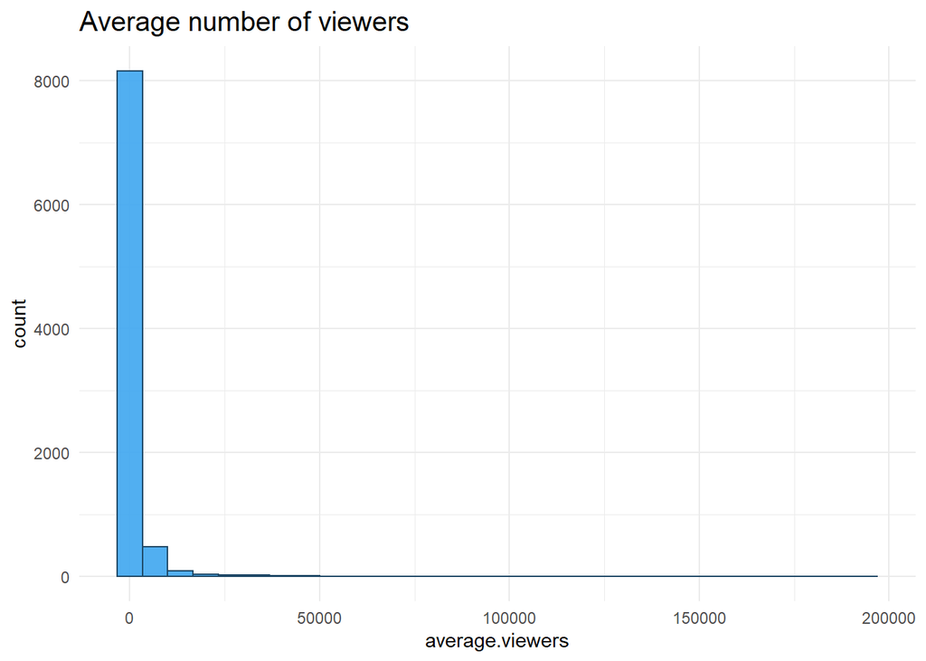

```r
ggplot(twitch, aes(x=average.viewers)) + geom_histogram(fill="#3ea6f0", color="#1f4866", alpha=0.9 ) + ggtitle("Average number of viewers") + theme_minimal() + theme(plot.title = element_text(size=15))
```

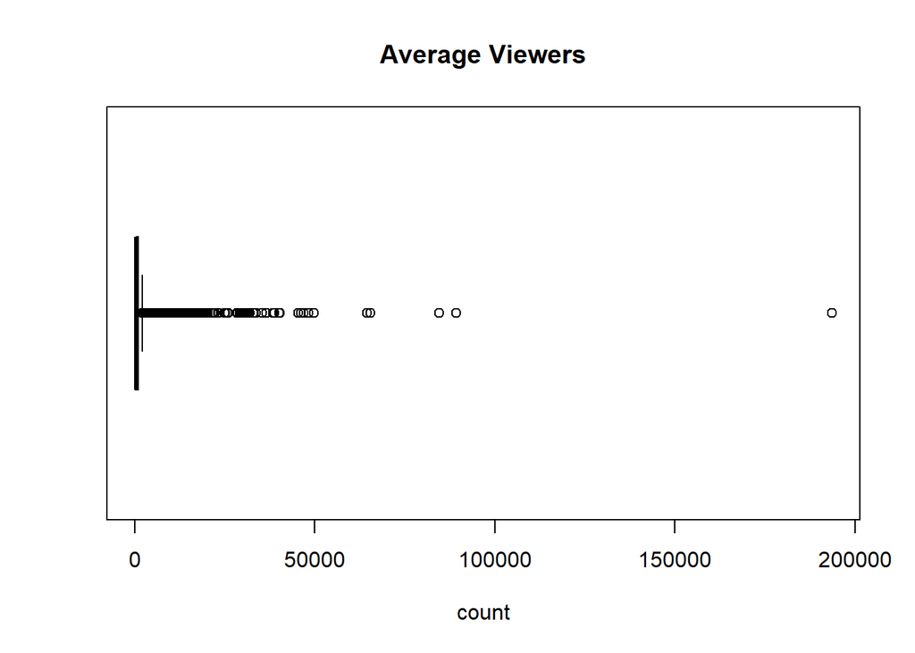

```r
boxplot(twitch$average.viewers, main="Average Viewers", horizontal=TRUE, xlab="count", col="darkolivegreen")
```

### 2.2.2 Correlation between variables

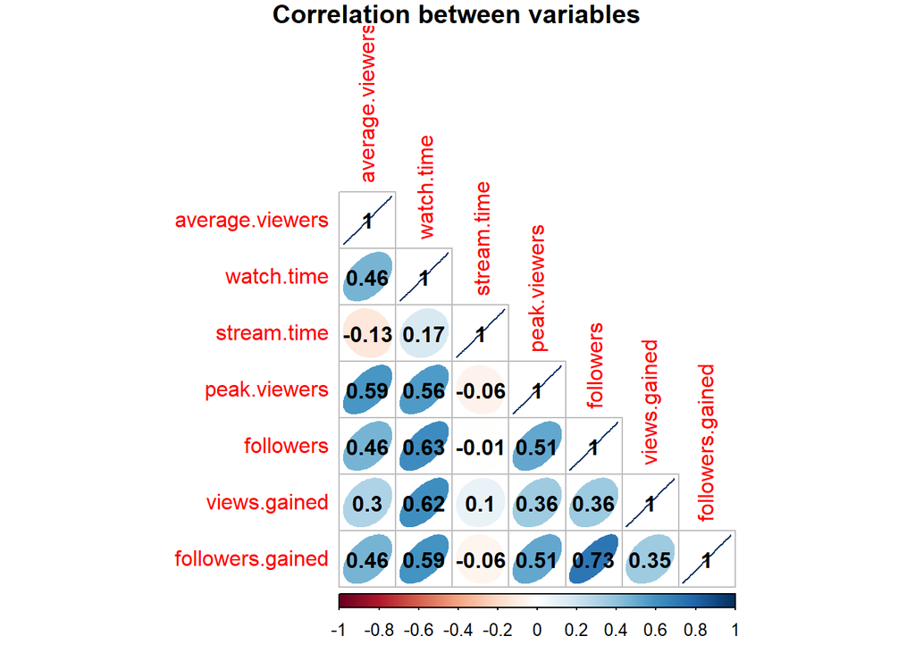

```r
# Correlation between variables
twitch.subset <- twitch[, c("average.viewers", "watch.time", "stream.time", "peak.viewers", "followers", "views.gained", "followers.gained" )]
corrplot(cor(twitch.subset),method="ellipse", type="lower",title="Correlation between variables",addCoef.col ="black",mar = c(0,0,1,0))
```

Looking at the correlation plots, almost every predictor has a positive correlation with **average.viewers** except **stream.time**. This makes sense because it is harder to hold a large consistent amount of viewers if you stream for long hours. Based on the correlation plot, it seems that **peak.viewers** is the most strongly correlated with **average.viewers**. Another important thing to note is that **watch.time** seems to be correlated with the other possible predictors, so there might be multicollinearity. **peak.viewers** might have a similar issue. **followers** and **followers.gained** are strongly correlated which makes sense, so I should be careful about that.

## 2.3 Q3: Simple Linear Regression

Based on the correlation plots, **peak.viewers** has the highest correlation with **average.viewers**, so I chose that predictor for the simple regression model.

```r
model1 <- lm(average.viewers ~ peak.viewers, data=twitch)
model1
```

```
##
## Call:
## lm(formula = average.viewers ~ peak.viewers, data = twitch)
##
## Coefficients:
##  (Intercept)  peak.viewers
##    389.20578       0.08654
```

```r
model1summary <- summary(model1)
model1summary
```

```
##
## Call:
## lm(formula = average.viewers ~ peak.viewers, data = twitch)
##
## Residuals:
##    Min     1Q Median     3Q    Max
## -69175   -437   -302    -52 173027
##
## Coefficients:
##               Estimate Std. Error t value Pr(>|t|)
## (Intercept)  3.892e+02  3.729e+01   10.44   <2e-16 ***
## peak.viewers 8.654e-02  1.275e-03   67.87   <2e-16 ***
## ---
## Signif. codes:  0 '***' 0.001 '**' 0.01 '*' 0.05 '.' 0.1 ' ' 1
##
## Residual standard error: 3285 on 8798 degrees of freedom
## Multiple R-squared:  0.3437, Adjusted R-squared:  0.3436
## F-statistic:  4607 on 1 and 8798 DF,  p-value: < 2.2e-16
```

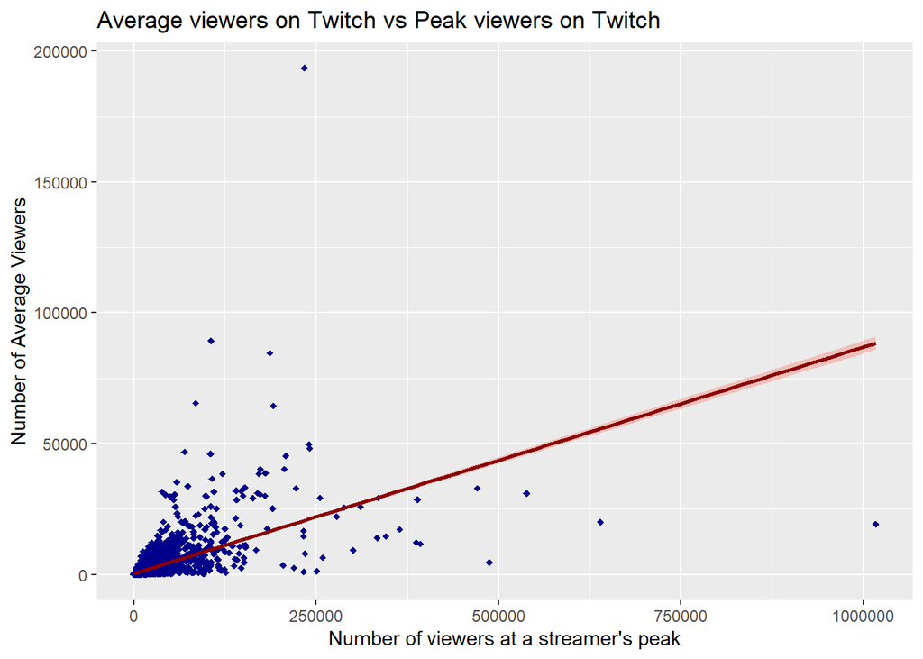

```r
ggplot(twitch, aes(x=peak.viewers, y=average.viewers)) +
  geom_point(shape=18, color="blue4") +
  ggtitle("Average viewers on Twitch vs Peak viewers on Twitch") +
  xlab("Number of viewers at a streamer's peak") +
  ylab("Number of Average Viewers") +
  geom_smooth(method=lm, color="darkred", fill="salmon")
```

The scatterplot, shows a positive linear relationship between average viewers and peak viewers, however, the variance seems to increase as the peak viewers increases. Additionally, there seem to be quite a few outliers in the data that could influence the regression line. I don’t believe that a transformation is necessary for this model.

The r-squared value from this mode is 0.34. This is not very high, but a t value of 67.87 for a hypothesis test of  
$H_0: b1 = 0$ and $H_1: b1 \ne 0$, indicates that this model is better than no model at all. The low r-squared value is likely due to the outliers that exist in the data and increase in variance as peak viewers increases.

### 2.3.1 Model assessment

#### 2.3.1.1 Linearity

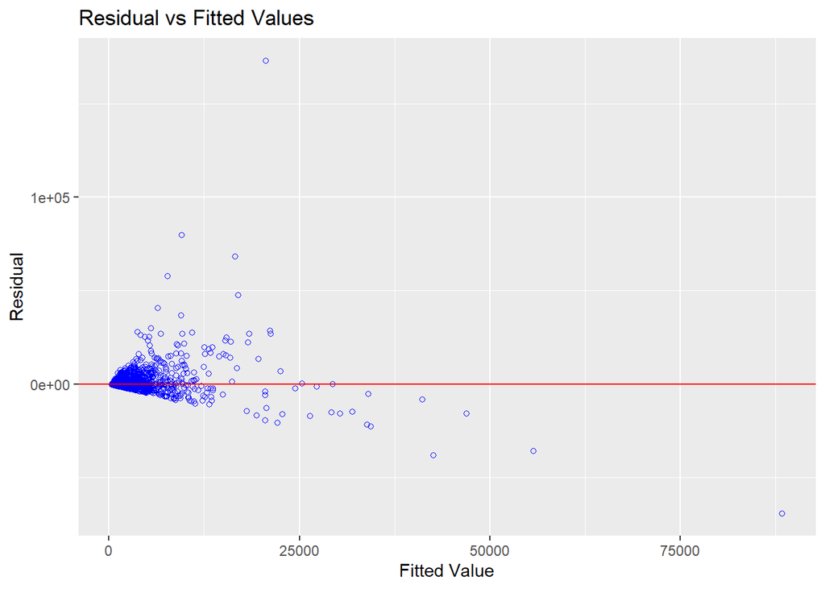

```r
# Residual plot
ols_plot_resid_fit(model1)
```

Based on this residual plot, there does not seem to be an obvious pattern that would suggest that the data is not linear, so the linear assumption is met.

#### 2.3.1.2 Normality

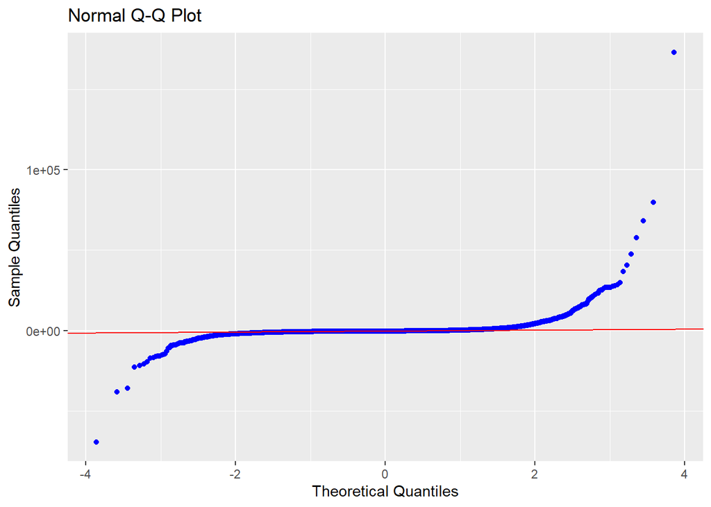

```r
# create QQ plot of residuals
ols_plot_resid_qq(model1)
```

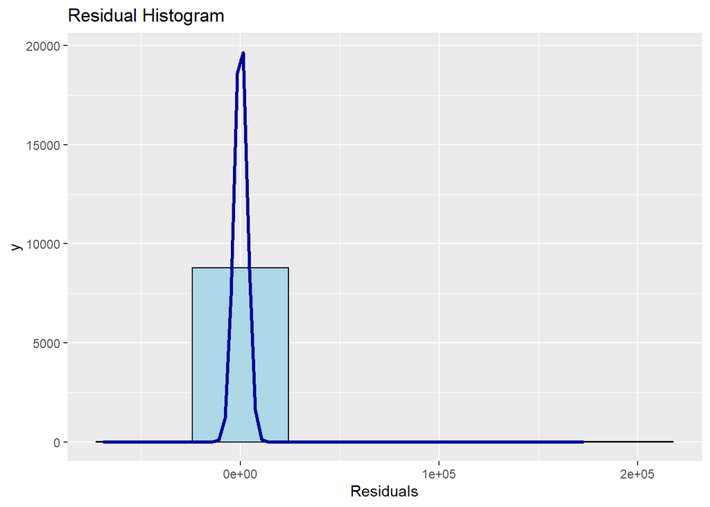

```r
# create a histogram of residuals
ols_plot_resid_hist(model1)
```

Looking at the QQ-Norm plot, it seems like the data points at the end of the model deviate from normal. Thus, the normal condition is not met.  
I should mention that the histogram of the residuals does not provide a good sense of the normality of the model. Also, I was unable to run the Wilks-Shapiro test because it has a limit on the number of observations it can process (at most 5000 observations).

### 2.3.2 Independence

The correlation plot showed that some possible predictor variables could be corrrelated. **watch.time** is a predictor that has a decently high correlation with **peak.viewers**, so the predictor is likely not independent. Thus, the independent condition is not met.

#### 2.3.2.1 Equal Variance

```r
# Breusch-Pagan Test
bptest(model1)
```

```
##
##  studentized Breusch-Pagan test
##
## data:  model1
## BP = 482.15, df = 1, p-value < 2.2e-16
```

Based on the fact the at the p-value for the Breusch-Pagan Test is low, the equal variance condition is not met. You can also see this on the residual plot because the variance gets larger as it continues.

#### 2.3.2.2 Outliers

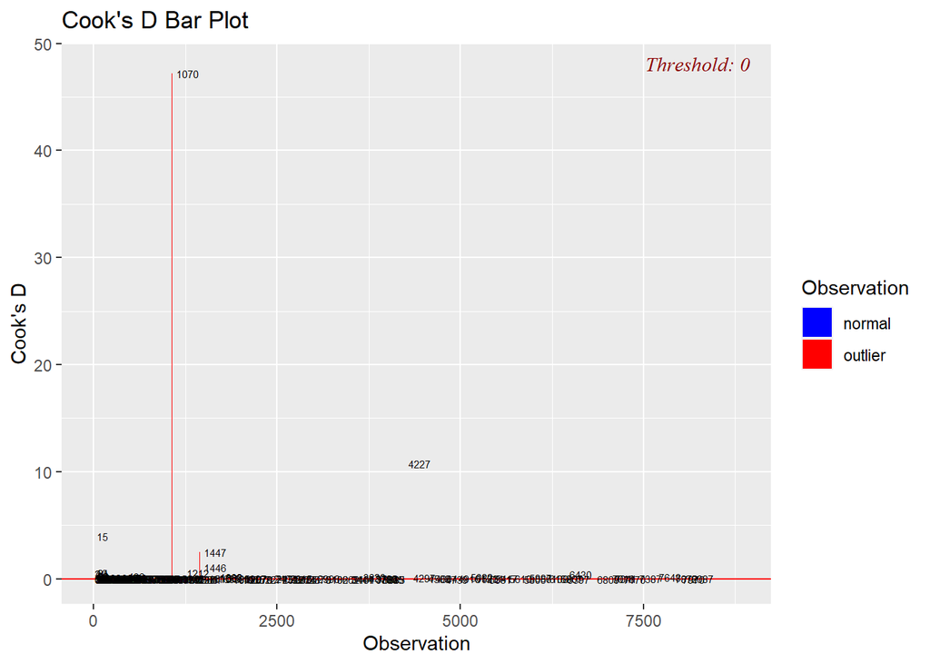

```r
ols_plot_cooksd_bar(model1)
```

Looking at the cook’s distance for the data points, there is one point that is very clearly an outlier compared to the others(data point 1070). There are 4 data points that have a Cook’s distance notably more than the others.

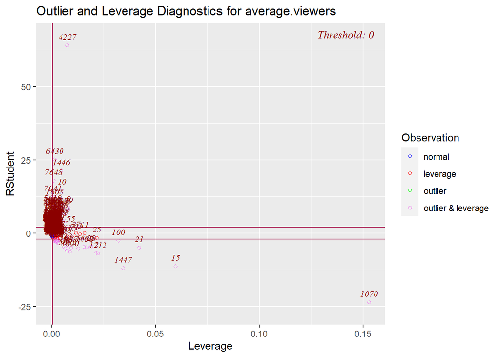

```r
ols_plot_resid_lev(model1)
```

Most of the data set is either normal or has high leverage, there are a few points out of the 8800 data points that are influential points. Once again 1070 shows up as an influential point. Additionally point 4227 is a notable influential point.

## 2.4 Q4: Multiple Regression

```r
#Here we try to find the best subset of the data to create the model with, using all the best numeric predictors.
subsetmodel <- lm(average.viewers ~ watch.time + stream.time + peak.viewers + followers + views.gained + followers.gained, data=twitch)
ols_step_best_subset(subsetmodel)
```

|  | mindex | n | predictors | rsquare | adjr | predrsq | cp | aic | sbic | sbc | msep | fpe | apc | hsp |
| --- | --- | --- | --- | --- | --- | --- | --- | --- | --- | --- | --- | --- | --- | --- |
| 3 | 1 | 1 | peak.viewers | 0.3436687 | 0.3435941 | 0.3231878 | 901.70275 | 167488.4 | 142514.7 | 167509.6 | 94981528350 | 10795809 | 0.6566297 | 1226.936 |
| 16 | 2 | 2 | peak.viewers followers | 0.3792432 | 0.3791021 | 0.3577942 | 378.06686 | 167000.0 | 142026.4 | 167028.3 | 89843542661 | 10212974 | 0.6211801 | 1160.697 |
| 32 | 3 | 3 | stream.time peak.viewers followers | 0.3887628 | 0.3885543 | 0.3674666 | 239.40996 | 166866.0 | 141892.5 | 166901.4 | 88475818779 | 10058640 | 0.6117932 | 1143.157 |
| 42 | 4 | 4 | watch.time stream.time peak.viewers followers | 0.4004756 | 0.4002029 | 0.3777233 | 68.34558 | 166697.7 | 141724.4 | 166740.2 | 86790269162 | 9868134 | 0.6002061 | 1121.507 |
| 58 | 5 | 5 | watch.time stream.time peak.viewers followers followers.gained | 0.4043248 | 0.4039861 | 0.3796769 | 13.47179 | 166643.1 | 141669.7 | 166692.6 | 86242851180 | 9807006 | 0.5964881 | 1114.560 |
| 63 | 6 | 6 | watch.time stream.time peak.viewers followers views.gained followers.gained | 0.4048981 | 0.4044920 | 0.3800539 | 7.00000 | 166636.6 | 141663.3 | 166693.3 | 86169638548 | 9799793 | 0.5960494 | 1113.740 |

Looking at the adj R-Squared values (adjr), the one with the highest value uses all six predictors. Additionally, the model with the lowest AIC is also the one that uses all six predictors, so I will chose that model for a more optimal model.

```r
#This model seems to be the best from the subset.
newmodel <- lm(average.viewers ~ watch.time + stream.time + peak.viewers + followers + views.gained + followers.gained, data=twitch)
```

### 2.4.1 Model assessment

Now we will test he LINE assumptions for the new model.

#### 2.4.1.1 Linearity

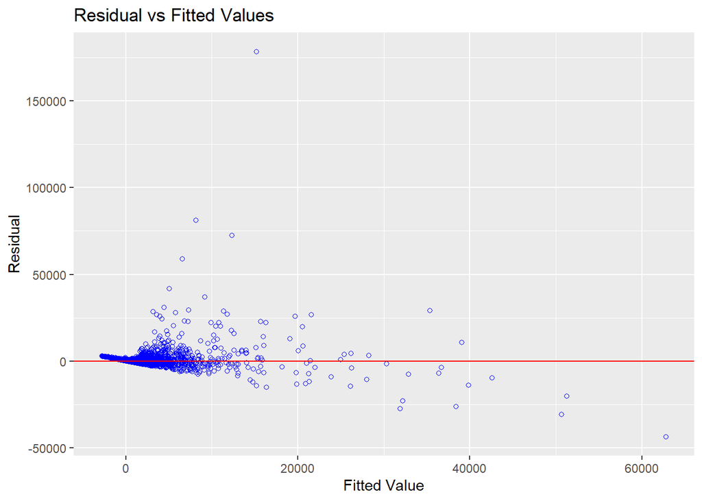

```r
# Residual plot
ols_plot_resid_fit(newmodel)
```

Looking at the residual plot, there does not seem to be any discernible pattern. Thus, the linear condition is good.

#### 2.4.1.2 Normality

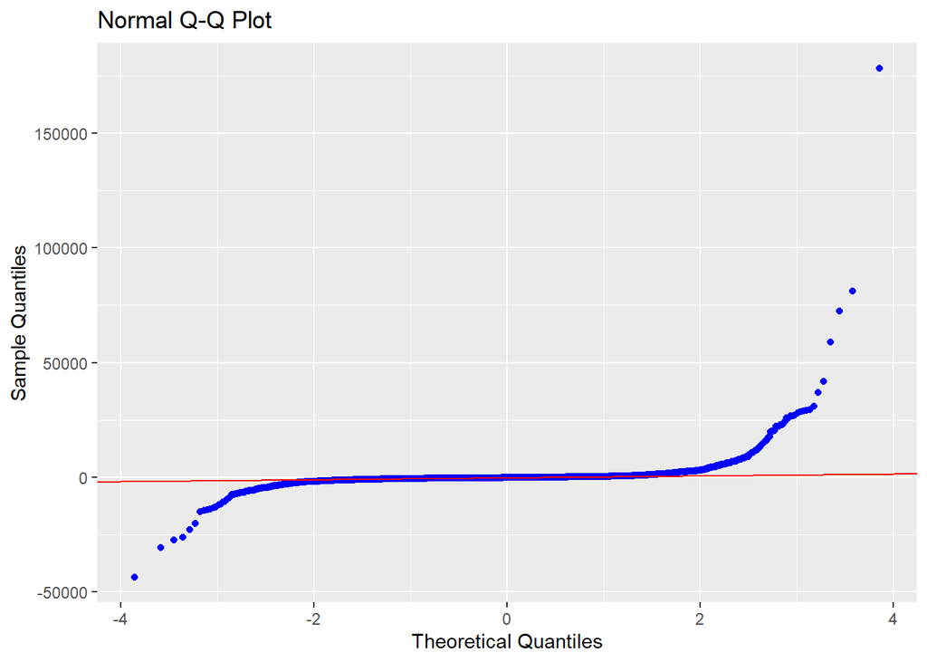

```r
# create QQ plot of residuals
ols_plot_resid_qq(newmodel)
```

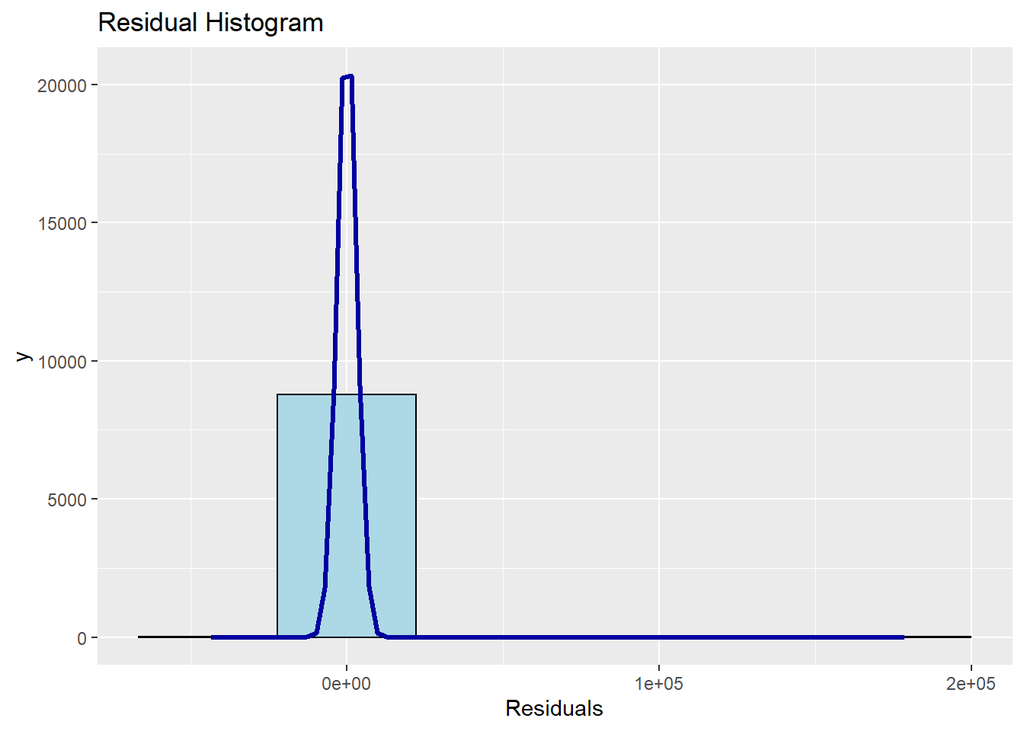

```r
# create a histogram of residuals
ols_plot_resid_hist(newmodel)
```

This model, unfortunately, seems to suffer from the same normality problem as the previous model. Thus, the normal condition is not met.

#### 2.4.1.3 Multicolinearity

```r
#Detecting multicolinearity
mc <- vif(newmodel)
knitr::kable(mc, col.names=c("VIF Score"))
```

|  | VIF Score |
| --- | --- |
| watch.time | 2.799425 |
| stream.time | 1.093007 |
| peak.viewers | 1.632391 |
| followers | 2.465236 |
| views.gained | 1.621726 |
| followers.gained | 2.355692 |

Based on the VIF scores, the model is not at great risk of having a multicollinearity problem because none of the VIF scores exceed 10.

#### 2.4.1.4 Equal Variance

```r
# Breusch-Pagan Test
bptest(newmodel)
```

```
##
##  studentized Breusch-Pagan test
##
## data:  newmodel
## BP = 368.29, df = 6, p-value < 2.2e-16
```

The p-value from the Breusch-Pagan test is very low. In fact, it has the same p-value as the other model. Therefore, the assumption of equal variance is broken.

#### 2.4.1.5 Outliers

Now we will check for potential influential points.

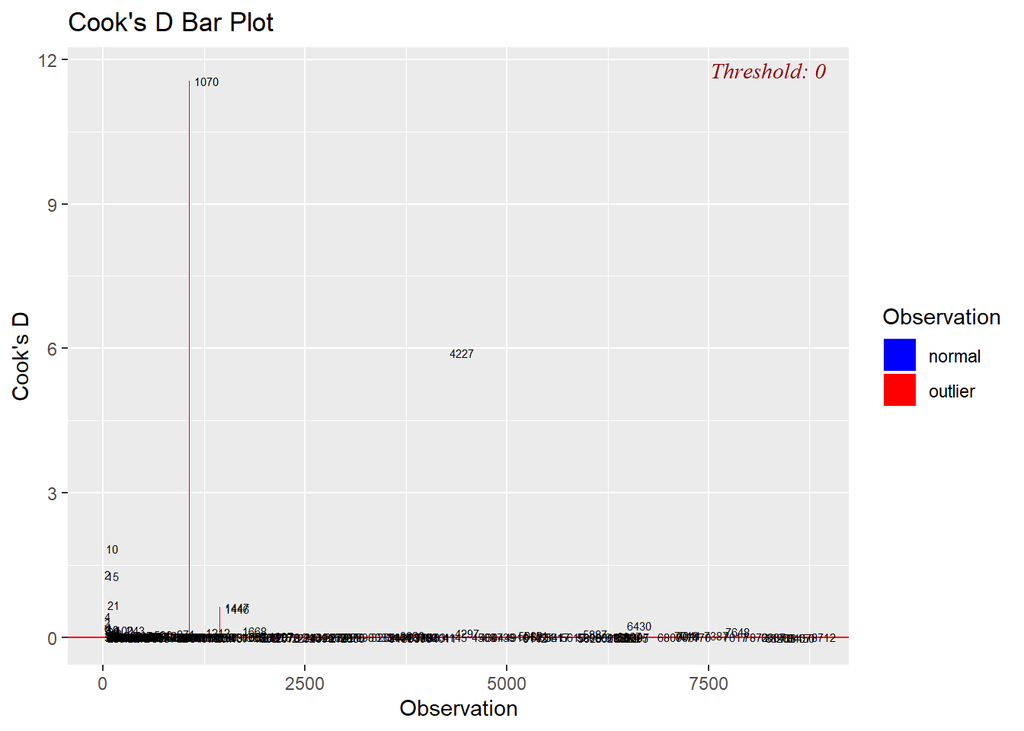

```r
ols_plot_cooksd_bar(newmodel)
```

Once again, data points 1070 and 4227 are notable outliers in the dataset, however, the Cook’s distance for the these points are much lower than before. The rest of the points have a Cook’s distance of less than 2.

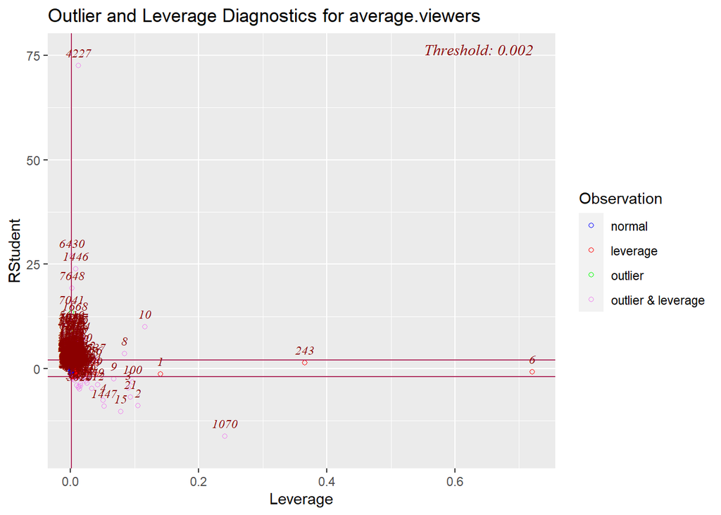

```r
ols_plot_resid_lev(newmodel)
```

Compared to the simple linear model, this model has very influential points like point 1070 and 4227, but they do not seem to be as influential as they were in the other model.

### 2.4.2 Comparing Multiple Regression Model vs Simple Model

I will now compare the models using an F-test at 1% significance.

$H_0: b2 = b3 = b4 = b5 = b6 = 0$ (All predictors, except peak.viewers don’t add anything to the model)  
$H_1: H_0$ is not true

```r
anova(model1, newmodel)
```

| Res.Df | RSS | Df | Sum of Sq | F | Pr(>F) |
| --- | --- | --- | --- | --- | --- |
| 8798 | 94959941638 | NA | NA | NA | NA |
| 8793 | 86101088951 | 5 | 8858852688 | 180.9405 | 0 |

Based on the F value of 180.94 which produces a p-value of 2.2e-16, we reject the null hypothesis and conclude that the multiple regression model, which includes six predictors, is better than the original model which only included peak.viewers as a predictor.

## 2.5 Q5: Hypothesis Testing

$H_0: b6 = 0$  
$H_1: b6 \ne 0$

```r
newmodelsummary <- summary(newmodel)
newmodelsummary
```

```
##
## Call:
## lm(formula = average.viewers ~ watch.time + stream.time + peak.viewers +
##     followers + views.gained + followers.gained, data = twitch)
##
## Residuals:
##    Min     1Q Median     3Q    Max
## -43585   -466   -224     87 178467
##
## Coefficients:
##                    Estimate Std. Error t value Pr(>|t|)
## (Intercept)       8.045e+02  5.811e+01  13.843  < 2e-16 ***
## watch.time        1.914e-06  2.280e-07   8.395  < 2e-16 ***
## stream.time      -7.097e-03  5.105e-04 -13.903  < 2e-16 ***
## peak.viewers      5.923e-02  1.552e-03  38.175  < 2e-16 ***
## followers         1.058e-03  1.327e-04   7.971 1.77e-15 ***
## views.gained      1.268e-05  4.358e-06   2.911  0.00362 **
## followers.gained  2.397e-03  3.173e-04   7.555 4.62e-14 ***
## ---
## Signif. codes:  0 '***' 0.001 '**' 0.01 '*' 0.05 '.' 0.1 ' ' 1
##
## Residual standard error: 3129 on 8793 degrees of freedom
## Multiple R-squared:  0.4049, Adjusted R-squared:  0.4045
## F-statistic: 997.1 on 6 and 8793 DF,  p-value: < 2.2e-16
```

## 2.6 Q6: Summary and Reflection

As a result of my study of the Twitch data, I determined that the best model to predict a Twitch streamer’s average viewership is the one with six predictors: **watch.time**, **stream.time**, **peak.viewers**, **followers**, **followers.gained**, and **views.gained**.

One of the insights I gained from this study is the fact that **stream.time** correlates negatively with the average viewership. This makes sense because streaming longer hours makes it more difficult to maintain a higher average viewership.

Additionally, a high peak viewership contributes to a higher average over the whole year. Higher total number of followers and the number of followers gained during the year imply a larger fanbase which tends to contribute to having more average viewers. Intuitively, a high watch time and views gained contributes to a higher average viewership as well.

Some difficulties I had with this study came from my inability to meet the LINE assumptions. Despite this, I think that this model provides some good insight into a Twitch streamer’s average viewership.

Finally, I think that there is an obvious difference between the super popular streamers in the dataset and the everyone else because there is a group of points that are considered outliers on the graph. I think separating the two groups and running a linear regression on them independently could be interesting.